# California Alloscoring - Forecasting 01/01/2022 at Two Different Horizons

Emily Tyszka

2026-02-10

# Background

## Allocation Score

When selecting a forecast or forecasts to make predictions of a given infectious disease outcome, there are a number quantitative measures of forecast accuracy, allowing for easy comparison between model performances. The existing methods, however, evaluate the forecasts entirely on whether how correct a forecast’s predictions can be considered to be, which may or may not translate to well-informed decision-making when the model is applied in practice. In short, it is an issue of accuracy vs. utility.

The allocation score, introduced by [Gerding et al. in 2024](https://academic.oup.com/jrsssa/article/188/4/1299/7927906), scores forecasts instead on their success in allocating limited medical resources across multiple locations. For a given forecast date, time horizon, and resource limitation, an forecast is evaluated across all locations together, penalizing any instance where resources are underallocated to a location (relative to the best possible allocation).

### Overview:

In its simplest form, this scoring framework:

1. Identifies a set of limited resources* of count K, which will be distributed across the locations based on their forecasts.
2. Compiles a set of disease burden forecasts for multiple locations (ex. forecasts for all counties in a state) and distributes the limited resources according to the forecast’s predictions of disease burden (ie. predicted need) in those locations.
3. Using the finalized truth data, generates an ideal “oracle” distribution that would be made by a decision-maker with knowledge of the true need.
4. Calculates total avoidable unmet need:
   1. Total unmet need: For each forecast and target date, underallocation is summed across all locations. Where more resources than are needed are allocated, this number is 0.
   2. Total unavoidable unmet need: If there are fewer resources than total need, the oracle may underallocate resources to some or all locations. As the oracle distribution is the best answer to the allocation problem, this underallocation is considered to be unavoidable. This is summed across all locations.
   3. Total avoidable unmet need = total unmet need - total unavoidable unmet need
5. This count of total avoidable unmet need is the **allocation score (AS)**. Lower alloscores indicate that resource distributions informed by the model result in less underallocation, indicating a better set of forecast estimates.

###### *Note: the resources in question remain theoretical, but are considered to be available for distribution to the locations of interest. For example, ventilators, PPE, or mobile staffing such as travel nurses may all be “sent” to a location that predicts higher resource need. Hospital beds, while in some ways able to be distributed (as through the setup of field hospitals) are less mobile and perhaps less suited to this particular thought experiment. Regardless, the actual resource does not matter, so long as it may be distributed across locations based on a set of forecasts, its need is expressed by the disease burden forecasts of interest, and it can be “wasted” if incorrectly distributed.

### Example:

Below, we see an simplified illustration of an allocation scoring scenario. In this scenario, 20,000 units of a resource are to be distributed between 4 counties of different populations at a set point in time. 3 allocation methods are being scored: one allocation proportional to county population and two allocations according to the predictions of forecasts. On the far right, the oracle distribution is shown in grey - note that it exhibits 800 units of unavoidable unmet need.

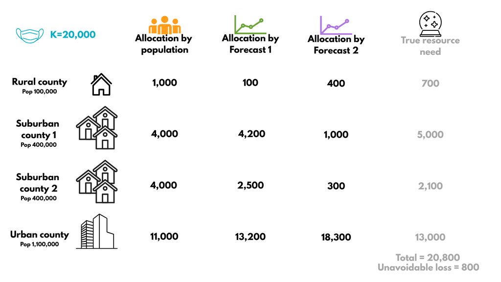

The 3 allocations are scored by first determining the unmet need for each location and model (ie. tallying all unmet need - where the allocation is less than the true resource need). Overallocation is not penalized.

For each allocation, underallocation is summed to find total unmet need, then unavoidable unmet need is subtracted from the value to give the alloscore. (For example, allocation by population had a total 3,000 units of need - subtracting 800 gives the alloscore of 2,200.)

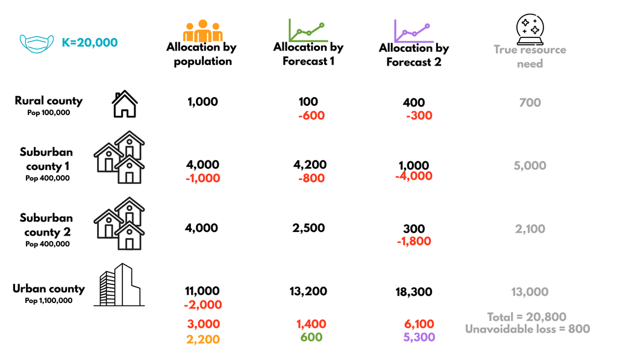

In this example method, we can treat the allocation by population as a control and use the alloscore to judge our two forecasts on how well they inform resource distribution decisions in the given scenario, when compared to an allocation that ignores predicted disease burden - in this example, Forecast 1 scored better, while Forecast 2 scored worse.

### AS for Probabilistic Forecasts:

Expanding upon this method for use with probabilistic forecasts, where predictions are expressed in terms of quantiles of a probability distribution, the basic allocation score method is expanded by:

- Generating a *loss function*, which expresses the sum of contributions from unmet need in each location, for a given allocation.
- Incorporating the probability distributions of each forecast, find the expected value of the loss function across all locations for the allocation of interest.
- Selecting the allocation which minimizes the value of the loss function.

# Project Justification and Goals

As far as we are aware, no researchers have attempted running the allocation score following the initial paper publication.

A major goal of this project is to repeat the scoring methodology on a new set of epidemic data and evaluate its performance and relevance to decisions made during the period of interest.

Additionally, we hope to observe how model performance, as measured via alloscore, differs between periods of higher and lower information on the part of forecasters (attempts to forecast a target date when the epidemic curve is not yet rising, versus when there is a clear rise occuring)

Finally, we aim to find ways to implement the alloscore at smaller geographic scales and in direct collaboration with a PH agency, inviting input and feedback.

# Experimental Outline

Here, we will be applying the allocation score to COVID-19 incident cases in California during the 2021-2022 peak, using county-level forecasts from the COVID-19 Forecast Hub. Allocation score will be calculated for all models with sufficient reported information for 01/01/2022 at 2 different time horizons: 1 week and 3 weeks prior to the date. Comparison of scores between models and dates, allocation results from the forecasts, and comparisons between AS and mWIS will be examined to explore allocation scoring for forecasts submitted during the omicron upswing.

## Dates of Interest

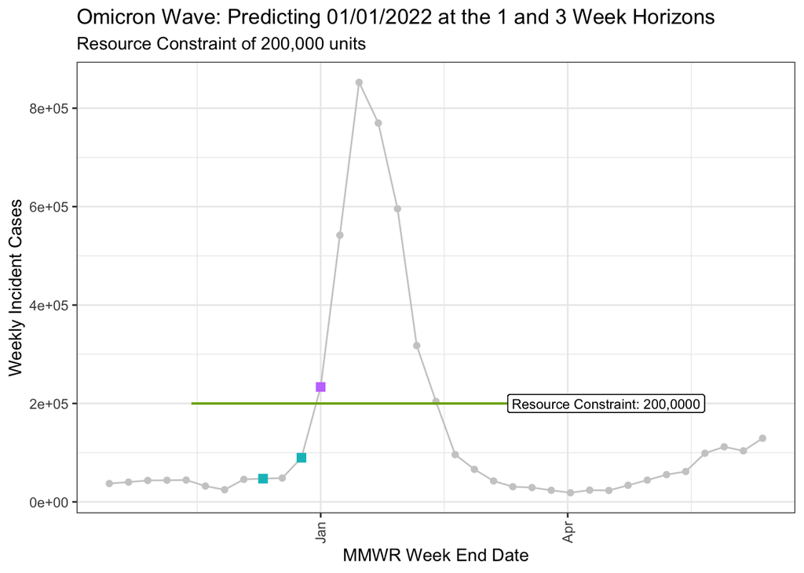

In the plot above, we see the omicron wave with this experiment’s dates of interest highlighted. The date of 01/01/2022 (shown in purple) is being forecast 3 weeks and 1 week prior (12/11/21 and 12/25/21 respectively, shown in teal).

**On these two dates, forecasters were operating with different levels of information regarding the coming peak.** On 12/11, the epidemic curve did not yet show a notable rise in cases, while forecasters on 12/25 could see this trend in its early stages. Additionally, the forecasts on 12/25 had the advantage of a shorter time horizon (1 week vs. 3 weeks.) Finally, it should be noted that since the forecasting target is reported cases, which is one of the earliest indicators of infectious disease activity, forecasters on neither date had the benefit of a strong leading indicator of activity. This is in contrast with other disease metrics that lag case counts, such as (for example) hospitalization or death forecasts, for which forecasting may be somewhat easier.

## Models Examined

### Glossary

- **Horizon**: The number of weeks into the future being predicted. For example, a forecast of disease activity on 11/21/2020 that was submitted on 11/07/2020 would be at the 2 week horizon.
- **Location**: In this experiment, the locations of interest were counties in the state of California (n=58). Because the allocation score method is attempting to solve a resource problem across all of these locations, forecasts were only included for a given target date and horizon if they submitted predictions for all 58 counties.
- **Reference Date:** This date marks when the forecast was submitted. More specifically, it is the Saturday of the week when the forecast was due to the hub.
- **Target End Date**: This date marks the week being forecast. More specifically, it is the Saturday ending the MMWR week of interest. Forecasts with the same target end date are predicting the same week’s measure of disease activity. A model could predict the same target end date multiple times at different horizons (ex. 3 weeks prior, 2 weeks prior, 1 week prior)
  - Reference Date + (7 x Horizon) = Target End Date

### Reported Forecasts

The original code for Gerding et al. contains scripts for model selection, filtering for reporting completeness across multiple horizons and all locations (n=58). The plot below summarizes which models were analyzed, based on reporting completeness - a model reporting 58 predictions for a given date and horizon is considered to have complete forecasts.

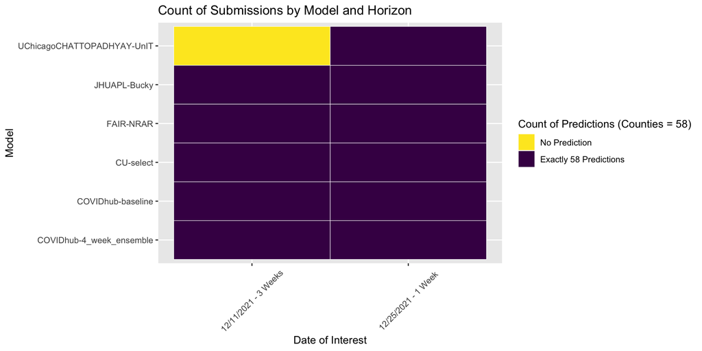

### Predictions

Here we can visualize the weekly incident cases by county for 9 counties of varying populations. Ranking the 58 counties by population, we examine the top 3 counties (LA County, San Diego County, Orange County), the middle counties of rank 29-31 (El Dorado County, Shasta County, CA Imperial County), and the 3 bottom population counties (Modoc County, Sierra County, Alpine County)

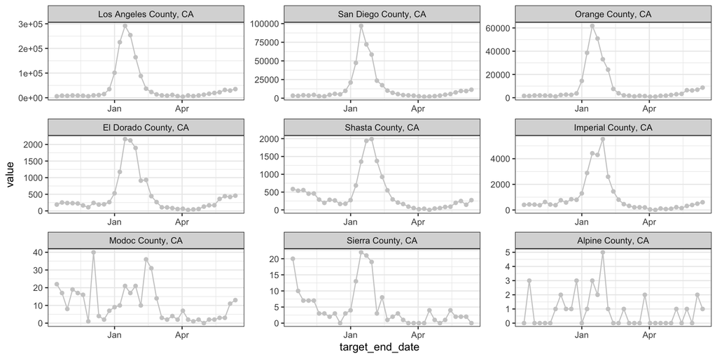

### 12/11/2021

We can visualize the forecasts

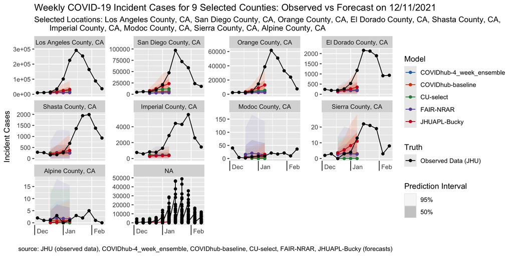

### 12/25/2021

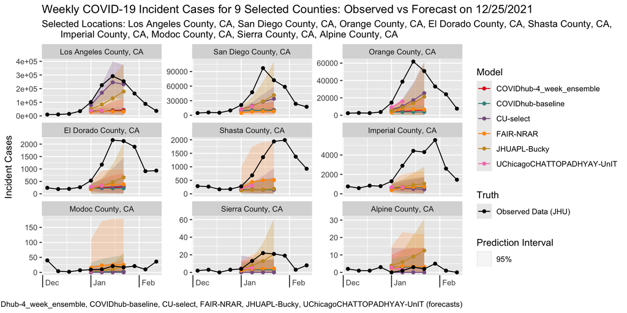

## Measures of Model Performance

In this experiment, **allocation score (AS)** was calculated for all forecasts, using a resource constraint of 200,000 units. As a control, AS was also assessed for a “per-capita” allocation that allocated resources based on 2020-2025 county level estimates of county populations as reported by the CA Department of Finance ([link here](https://dof.ca.gov/forecasting/demographics/estimates/)).

Relative rankings of AS for the models were compared to **weighted interval score (WIS)** (with the exception of the per-capita allocation, which wasn’t probabilistic and therefore WIS could not be calculated). Kendall’s tau a was used to explore the relationship between these rankings.

Finally, under- and overallocation was visualized for each model and reference date across all locations, allowing for a more detailed examination of trends in the model-based decision-making.

# Results

## 3 Week Horizon: 12/11/2021

At the 3 week horizon, the FAIR-NRAR was the only model to outperform the COVIDhub-baseline model in allocation score, and these models were the only ones to make an improvement over a per-capita allocation.

We note that the mWIS rankings differ from the allocation score rankings - which models were “best” differed between the evaluation metrics.

2021-12-11: Model scoring for the 3 week horizon (2022-01-01). Allocations conducted with a resource constraint of 200,000 units.

| model | alloscore | allo_rank | mwis | mwis_rank |
| --- | --- | --- | --- | --- |
| FAIR-NRAR | 7916.234 | 1 | 2657.881 | 5 |
| COVIDhub-baseline | 9296.581 | 2 | 2652.446 | 4 |
| per-capita | 11175.244 | 3 | NA | NA |
| CU-select | 11985.119 | 4 | 2476.182 | 2 |
| JHUAPL-Bucky | 12420.848 | 5 | 1470.841 | 1 |
| COVIDhub-4_week_ensemble | 13901.726 | 6 | 2606.029 | 3 |

### Kendall’s Tau A

A negative coefficient on these scores shows this difference between mWIS and allocation score rankings. (Note that the small sample size makes a judgement of statistical significance impossible here)

```
##
##  Kendall's rank correlation tau
##
## data:  summary3_200$alloscore and summary3_200$mwis
## T = 2, p-value = 0.2333
## alternative hypothesis: true tau is not equal to 0
## sample estimates:
##  tau
## -0.6
```

### Allocation by County

Here we adapt a plot from Gerding *et al.* to visualize under/overallocation. However, due to great disparities in county size, this plot is difficult to interpret.

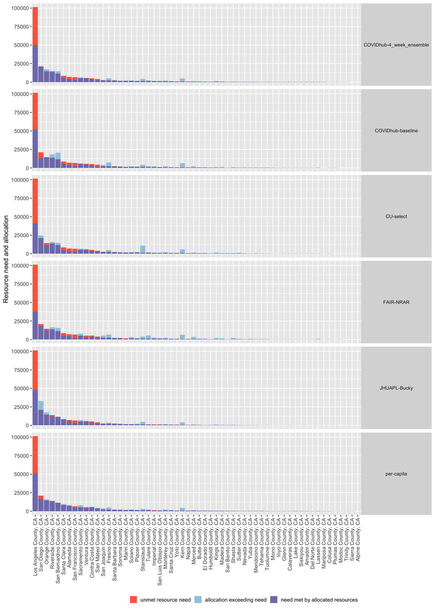

Examining our population ranked subset counties from earlier makes this a bit easier to understand:

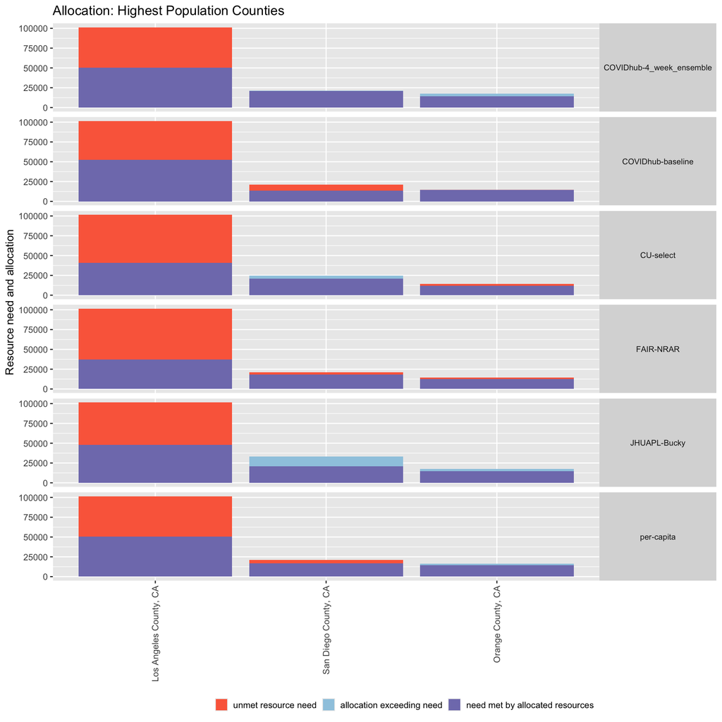

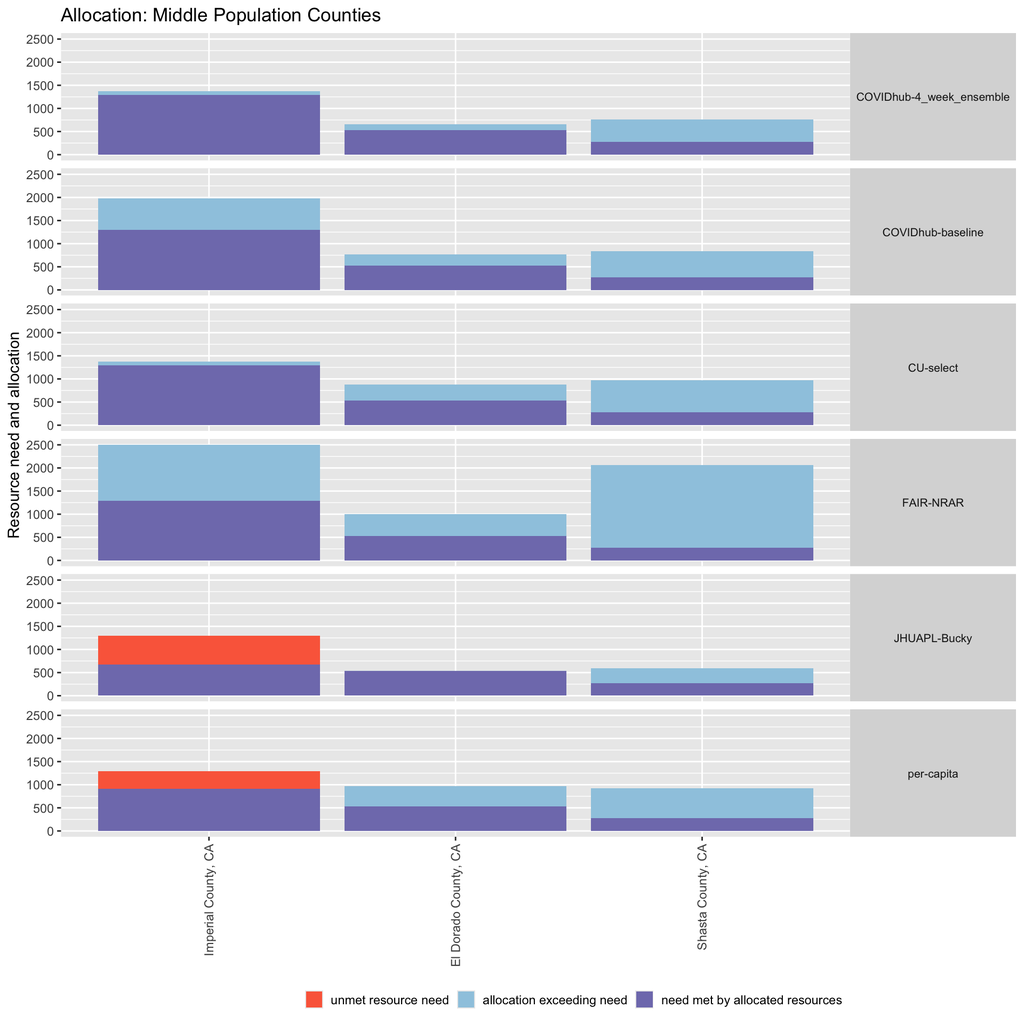

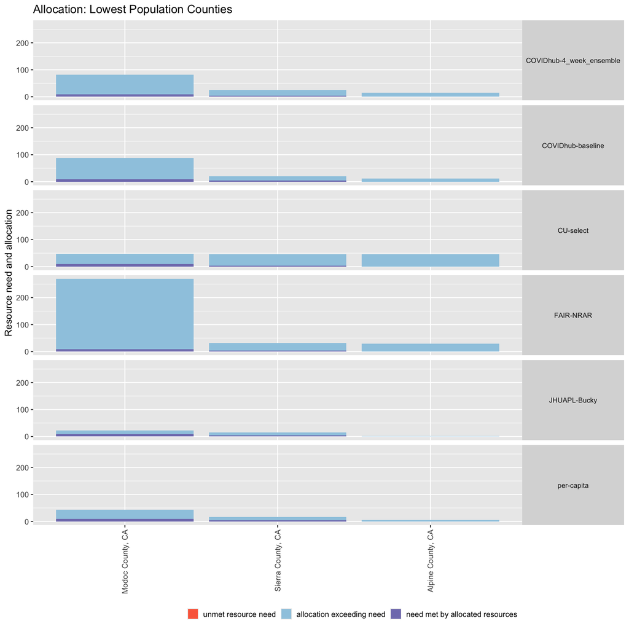

For all 6 methods, we see underallocation to LA county at this horizon. Looking to the lower population counties, we see more overallocation as we move to lower population counties.

## 1 Week Horizon: 12/25/2021

In absolute sense, we see these allocations scores are slightly lower 1 week horizon than in the 3 week horizon.

At the 1 week horizon, only the COVIDhub-4_week_ensemble was able to beat the COVIDhub-baseline allocation score. Along with these 2, we also see the FAIR-NRAR and JHUAPHL-Bucky models beating out the per-capita allocation in alloscore.

Again, the mWIS and alloscore rankings don’t track well to each other.

2021-12-25: Model scoring for the 1 week horizon (2022-01-01). Allocations conducted with a resource constraint of 200,000 units.

| model | alloscore | allo_rank | mwis | mwis_rank |
| --- | --- | --- | --- | --- |
| COVIDhub-4_week_ensemble | 3832.221 | 1 | 2050.397 | 4 |
| COVIDhub-baseline | 8679.357 | 2 | 2206.611 | 6 |
| FAIR-NRAR | 8693.015 | 3 | 2080.370 | 5 |
| JHUAPL-Bucky | 10805.764 | 4 | 1587.284 | 2 |
| per-capita | 11175.244 | 5 | NA | NA |
| CU-select | 11579.068 | 6 | 1393.780 | 1 |
| UChicagoCHATTOPADHYAY-UnIT | 14958.666 | 7 | 1940.026 | 3 |

### Kendall’s Tau A

```
##
##  Kendall's rank correlation tau
##
## data:  summary1_200$alloscore and summary1_200$mwis
## T = 4, p-value = 0.2722
## alternative hypothesis: true tau is not equal to 0
## sample estimates:
##        tau
## -0.4666667
```

Kendall’s tau again gives us a negative coefficient for the rankings of these 2 scores.

### Allocation by County

Again, under/overallocation is difficult to visualize with all counties.

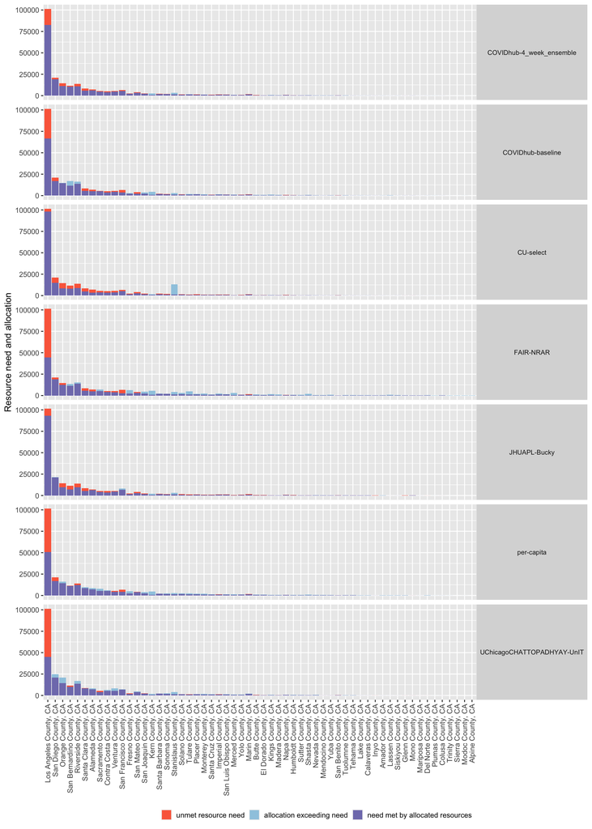

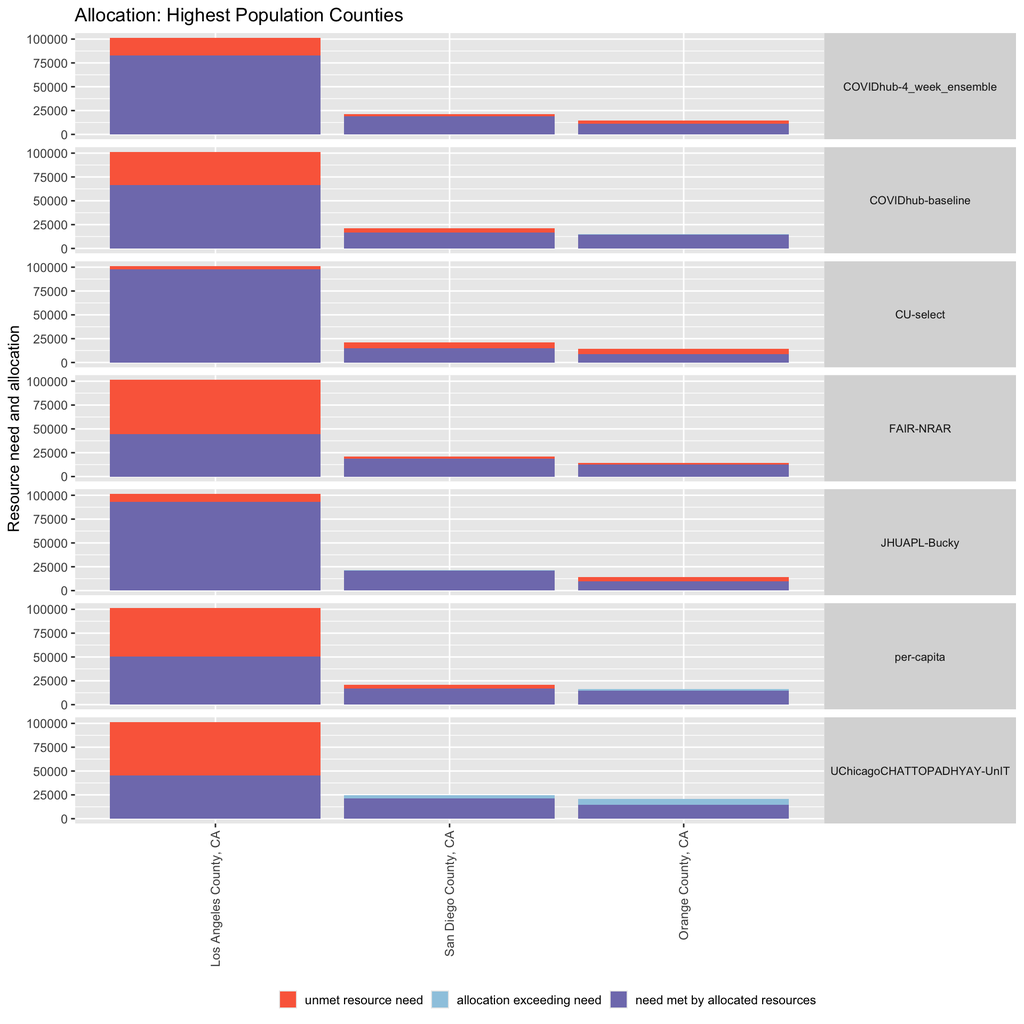

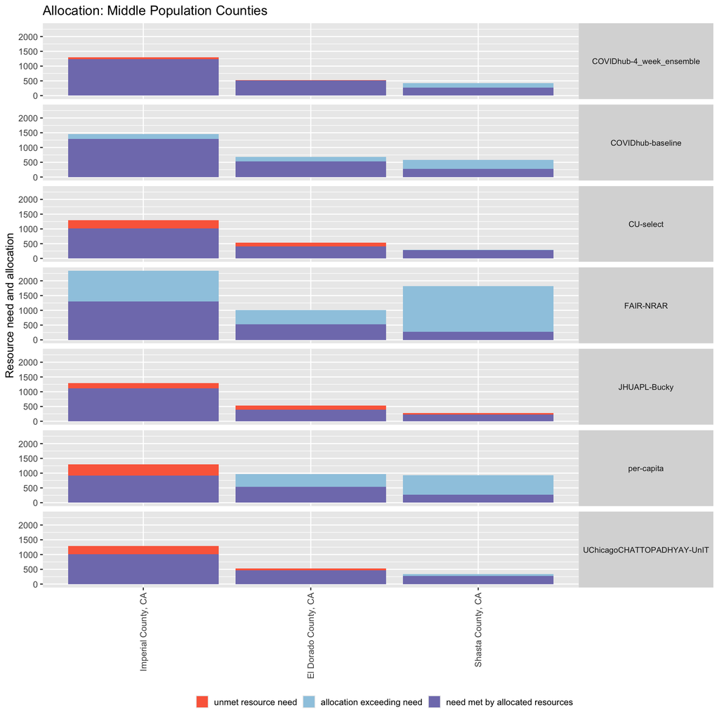

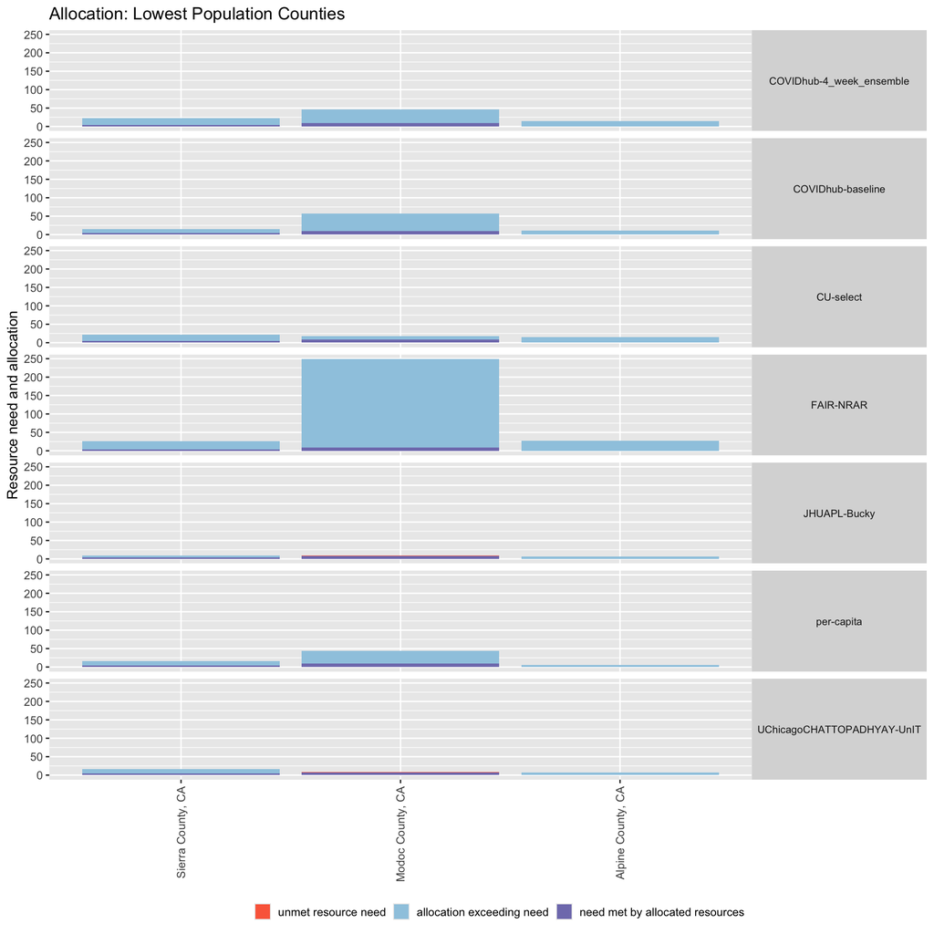

# Key Takeaways

**Results**

- Across the board, models underallocated to LA County for the date of 01/01/2022, while mostly overallocating to smaller counties. At this target date, it is likely that LA county was being particularly hard-hit by covid-19.
- Allocation scores seemed slightly lower in the 1 week horizon than in the 3 week horizon. This could be because of the horizon and/or because of the lack of discernible trend on 12/11 (most likely both)
- With the exception of FAIR-NRAR and the COVIDhub ensemble model, most tested models failed to score better than the COVIDhub baseline on the allocation score. However, some models did rank better than the per-capita allocation in the 1-week time horizon.
  - Through comparisons to both of these controls, it is possible to categorize our models in groups from least to most value added.
  - Beating the per-capita allocation shows that a model has improved upon the allocation by taking time series information into account. (The per-capita is based on population *only*)
  - Beating the baseline model shows that the model results in a better allocation than one based just on current counts. (The baseline is based on most recent observed incidence.)
- Relative rankings of forecasts for mWIS and allocation score did not track neatly to each other. Very frequently, a well performing model on the allocation score was one of the worst on the mWIS and vice versa.

**General considerations for the alloscore**:

- *Time horizon* - weeks before target date
- *High vs. low information time periods -* is a trend easy to discern in the present data?
- *County disparities* - performance when 1 county is particularly hard-hit or doesn’t follow the trend of other counties
- *Comparison to mWIS* (and what this means)

# Possible Areas of Exploration

- mWIS and alloscore relationship (or, more accurately, inverse relationship)
- Untangling impact of time horizon from the amount of information in the current epidemic curve
- Examples of allocation decisions made at the state level and time points